# Project: Investigate a Dataset - TMDb Movie Data

- Introduction
- Data Wrangling
- Exploratory Data Analysis
- Conclusions

## Introduction

### Dataset Description

> I chose the movies data set. *This data set contains information about 10,000 movies collected from The Movie Database (TMDb), including user ratings and revenue*.

All Columns that appear in the *raw* data set:

1- id: Unique identifier for each movie.

2- imdb_id: IMDB identifier for the movie, useful for looking up movies on IMDB.

3- popularity: Numeric score representing the popularity of the movie.

4- budget: The production budget of the movie, usually in USD.

5- revenue: The total profits the movie earned, usually in USD.

6- title: The title of the movie.

7- cast: List of main actors in the movie.

8- homepage: URL of the movie's official homepage.

9- director: Name(s) of the director(s) of the movie.

10- tagline: A short promotional phrase or catchphrase for the movie.

11- keywords: Keywords or phrases related to the movie's content or themes.

12- overview: Brief description or synopsis of the movie.

13- runtime: Length of the movie in minutes.

14- genres: Genres associated with the movie, such as Action, Comedy, etc.

15- production_companies: Companies involved in producing the movie.

16- release_date: Release date of the movie.

17- vote_count: Total number of votes the movie received from users.

18- vote_average: Average rating of the movie based on user votes (often out of 10).

19- release_year: The year in which the movie was released.

20- budget_adj: Adjusted budget, possibly taking inflation into account.

21- revenue_adj: Adjusted revenue, possibly accounting for inflation.

I chose to keep columns number(1, 3, 4, 5, 9, 13, 14, 17, 18, 19). Since these are the columns I'm going to need in my investigation.

### Questions for Analysis

**I'm planning to explore the following questions:**

1- Does the runtime of a movie correlate with its popularity or revenue?

2- Which directors have the most high-revenue movies?

3- Which movies are most popular from year to year?

4- What kinds of properties are associated with movies that have high revenues?

```python
#importing necessary libraries
import pandas as pd
import numpy as np

%matplotlib inline
```

## Data Wrangling

```python
# Load my data and the size of it
df = pd.read_csv('tmdb-movies.csv')

df.shape   #(10866, 21)
```

```
(10866, 21)
```

```python
df.head(10)
```

|  | id | imdb_id | popularity | budget | revenue | original_title | cast | homepage | director | tagline | ... | overview | runtime | genres | production_companies | release_date | vote_count | vote_average | release_year | budget_adj | revenue_adj |
| --- | --- | --- | --- | --- | --- | --- | --- | --- | --- | --- | --- | --- | --- | --- | --- | --- | --- | --- | --- | --- | --- |
| 0 | 135397 | tt0369610 | 32.985763 | 150000000 | 1513528810 | Jurassic World | Chris Pratt\|Bryce Dallas Howard\|Irrfan Khan\|Vi... | http://www.jurassicworld.com/ | Colin Trevorrow | The park is open. | ... | Twenty-two years after the events of Jurassic ... | 124 | Action\|Adventure\|Science Fiction\|Thriller | Universal Studios\|Amblin Entertainment\|Legenda... | 6/9/15 | 5562 | 6.5 | 2015 | 1.379999e+08 | 1.392446e+09 |
| 1 | 76341 | tt1392190 | 28.419936 | 150000000 | 378436354 | Mad Max: Fury Road | Tom Hardy\|Charlize Theron\|Hugh Keays-Byrne\|Nic... | http://www.madmaxmovie.com/ | George Miller | What a Lovely Day. | ... | An apocalyptic story set in the furthest reach... | 120 | Action\|Adventure\|Science Fiction\|Thriller | Village Roadshow Pictures\|Kennedy Miller Produ... | 5/13/15 | 6185 | 7.1 | 2015 | 1.379999e+08 | 3.481613e+08 |
| 2 | 262500 | tt2908446 | 13.112507 | 110000000 | 295238201 | Insurgent | Shailene Woodley\|Theo James\|Kate Winslet\|Ansel... | http://www.thedivergentseries.movie/#insurgent | Robert Schwentke | One Choice Can Destroy You | ... | Beatrice Prior must confront her inner demons ... | 119 | Adventure\|Science Fiction\|Thriller | Summit Entertainment\|Mandeville Films\|Red Wago... | 3/18/15 | 2480 | 6.3 | 2015 | 1.012000e+08 | 2.716190e+08 |
| 3 | 140607 | tt2488496 | 11.173104 | 200000000 | 2068178225 | Star Wars: The Force Awakens | Harrison Ford\|Mark Hamill\|Carrie Fisher\|Adam D... | http://www.starwars.com/films/star-wars-episod... | J.J. Abrams | Every generation has a story. | ... | Thirty years after defeating the Galactic Empi... | 136 | Action\|Adventure\|Science Fiction\|Fantasy | Lucasfilm\|Truenorth Productions\|Bad Robot | 12/15/15 | 5292 | 7.5 | 2015 | 1.839999e+08 | 1.902723e+09 |
| 4 | 168259 | tt2820852 | 9.335014 | 190000000 | 1506249360 | Furious 7 | Vin Diesel\|Paul Walker\|Jason Statham\|Michelle ... | http://www.furious7.com/ | James Wan | Vengeance Hits Home | ... | Deckard Shaw seeks revenge against Dominic Tor... | 137 | Action\|Crime\|Thriller | Universal Pictures\|Original Film\|Media Rights ... | 4/1/15 | 2947 | 7.3 | 2015 | 1.747999e+08 | 1.385749e+09 |
| 5 | 281957 | tt1663202 | 9.110700 | 135000000 | 532950503 | The Revenant | Leonardo DiCaprio\|Tom Hardy\|Will Poulter\|Domhn... | http://www.foxmovies.com/movies/the-revenant | Alejandro González Iñárritu | (n. One who has returned, as if from the dead.) | ... | In the 1820s, a frontiersman, Hugh Glass, sets... | 156 | Western\|Drama\|Adventure\|Thriller | Regency Enterprises\|Appian Way\|CatchPlay\|Anony... | 12/25/15 | 3929 | 7.2 | 2015 | 1.241999e+08 | 4.903142e+08 |
| 6 | 87101 | tt1340138 | 8.654359 | 155000000 | 440603537 | Terminator Genisys | Arnold Schwarzenegger\|Jason Clarke\|Emilia Clar... | http://www.terminatormovie.com/ | Alan Taylor | Reset the future | ... | The year is 2029. John Connor, leader of the r... | 125 | Science Fiction\|Action\|Thriller\|Adventure | Paramount Pictures\|Skydance Productions | 6/23/15 | 2598 | 5.8 | 2015 | 1.425999e+08 | 4.053551e+08 |
| 7 | 286217 | tt3659388 | 7.667400 | 108000000 | 595380321 | The Martian | Matt Damon\|Jessica Chastain\|Kristen Wiig\|Jeff ... | http://www.foxmovies.com/movies/the-martian | Ridley Scott | Bring Him Home | ... | During a manned mission to Mars, Astronaut Mar... | 141 | Drama\|Adventure\|Science Fiction | Twentieth Century Fox Film Corporation\|Scott F... | 9/30/15 | 4572 | 7.6 | 2015 | 9.935996e+07 | 5.477497e+08 |
| 8 | 211672 | tt2293640 | 7.404165 | 74000000 | 1156730962 | Minions | Sandra Bullock\|Jon Hamm\|Michael Keaton\|Allison... | http://www.minionsmovie.com/ | Kyle Balda\|Pierre Coffin | Before Gru, they had a history of bad bosses | ... | Minions Stuart, Kevin and Bob are recruited by... | 91 | Family\|Animation\|Adventure\|Comedy | Universal Pictures\|Illumination Entertainment | 6/17/15 | 2893 | 6.5 | 2015 | 6.807997e+07 | 1.064192e+09 |
| 9 | 150540 | tt2096673 | 6.326804 | 175000000 | 853708609 | Inside Out | Amy Poehler\|Phyllis Smith\|Richard Kind\|Bill Ha... | http://movies.disney.com/inside-out | Pete Docter | Meet the little voices inside your head. | ... | Growing up can be a bumpy road, and it's no ex... | 94 | Comedy\|Animation\|Family | Walt Disney Pictures\|Pixar Animation Studios\|W... | 6/9/15 | 3935 | 8.0 | 2015 | 1.609999e+08 | 7.854116e+08 |

10 rows × 21 columns

```python
#getting more info about columns
df.info()
```

```
<class 'pandas.core.frame.DataFrame'>
RangeIndex: 10866 entries, 0 to 10865
Data columns (total 21 columns):
 #   Column                Non-Null Count  Dtype
---  ------                --------------  -----
 0   id                    10866 non-null  int64
 1   imdb_id               10856 non-null  object
 2   popularity            10866 non-null  float64
 3   budget                10866 non-null  int64
 4   revenue               10866 non-null  int64
 5   original_title        10866 non-null  object
 6   cast                  10790 non-null  object
 7   homepage              2936 non-null   object
 8   director              10822 non-null  object
 9   tagline               8042 non-null   object
 10  keywords              9373 non-null   object
 11  overview              10862 non-null  object
 12  runtime               10866 non-null  int64
 13  genres                10843 non-null  object
 14  production_companies  9836 non-null   object
 15  release_date          10866 non-null  object
 16  vote_count            10866 non-null  int64
 17  vote_average          10866 non-null  float64
 18  release_year          10866 non-null  int64
 19  budget_adj            10866 non-null  float64
 20  revenue_adj           10866 non-null  float64
dtypes: float64(4), int64(6), object(11)
memory usage: 1.7+ MB
```

### Data Cleaning

```python
# After discussing the structure of the data and any problems that need to be cleaned

#I started by removing unnecessary columnss for my investigation
#to optimize memory usage
df.drop(['imdb_id', 'release_date', 'original_title', 'cast', 'homepage', 'tagline', 'keywords', 'overview', 'production_companies' , 'revenue_adj' , 'budget_adj'], axis=1, inplace=True)
df.info()
```

```
<class 'pandas.core.frame.DataFrame'>
RangeIndex: 10866 entries, 0 to 10865
Data columns (total 10 columns):
 #   Column        Non-Null Count  Dtype
---  ------        --------------  -----
 0   id            10866 non-null  int64
 1   popularity    10866 non-null  float64
 2   budget        10866 non-null  int64
 3   revenue       10866 non-null  int64
 4   director      10822 non-null  object
 5   runtime       10866 non-null  int64
 6   genres        10843 non-null  object
 7   vote_count    10866 non-null  int64
 8   vote_average  10866 non-null  float64
 9   release_year  10866 non-null  int64
dtypes: float64(2), int64(6), object(2)
memory usage: 849.0+ KB
```

```python
#removing duplicates
sum(df.duplicated())
df.drop_duplicates(inplace=True)
```

```python
#dropping null values rows for director & genres columns
#as genre & directors are central to some questions.dropping those rows may be best since they will affect my results
df.dropna(inplace=True)

print(df['director'].isnull().sum())    #to make sure no null values are left
print(df['genres'].isnull().sum())      #to make sure no null values are left

df.info()
```

```
0
0
<class 'pandas.core.frame.DataFrame'>
Int64Index: 10800 entries, 0 to 10865
Data columns (total 10 columns):
 #   Column        Non-Null Count  Dtype
---  ------        --------------  -----
 0   id            10800 non-null  int64
 1   popularity    10800 non-null  float64
 2   budget        10800 non-null  int64
 3   revenue       10800 non-null  int64
 4   director      10800 non-null  object
 5   runtime       10800 non-null  int64
 6   genres        10800 non-null  object
 7   vote_count    10800 non-null  int64
 8   vote_average  10800 non-null  float64
 9   release_year  10800 non-null  int64
dtypes: float64(2), int64(6), object(2)
memory usage: 928.1+ KB
```

```python
 # checking if budget col has any 0 values
df[df['budget']==0].shape
```

```
(5636, 10)
```

```python
#getting budget mean for non-zero values
budget_mean = df['budget'][df['budget'] > 0].mean()
budget_mean
```

```
30766902.224825718
```

```python
#replacing each 0 value with the mean
df['budget'].replace(0, budget_mean, inplace=True)

#checking if non-zero values were replaced
df[df['budget']==0].shape
```

```
(0, 10)
```

```python
 # checking if revenue col has any 0 values
df[df['revenue']==0].shape
```

```
(5952, 10)
```

```python
#getting revenue mean for non-zero values
rev_mean =df['revenue'][df['revenue'] > 0].mean()
rev_mean
```

```
89254997.08642739
```

```python
#replacing each 0 value with the mean
df['revenue'].replace(0, rev_mean, inplace=True)
df[df['revenue']==0].shape
```

```
(0, 10)
```

```python
 # checking if runtime col has any 0 values
df[df['runtime']==0].shape

#getting revenue mean for non-zero values
runtime_mean =df['runtime'][df['runtime'] > 0].mean()

#replacing each 0 value with the mean
df['runtime'].replace(0, runtime_mean , inplace=True)
```

```python
 #creating a function that prints out the max & min values of a column
def Min_Max(a):
    print("Minimum Value:" , a.min())
    print("Maximum Value:", a.max())
```

```python
#creating a functions that prints out the floats & ints ranges
def floats_ranges():
        print("float16: min:" , np.finfo("float16").min , "| max: ", np.finfo("float16").max )
        print("float32: min:" , np.finfo("float32").min , "| max: ", np.finfo("float32").max )
        print("float64: min:" , np.finfo("float64").min , "| max: ", np.finfo("float64").max )


def ints_ranges():
        print(np.iinfo("int8"))
        print(np.iinfo("int16"))
        print(np.iinfo("int32"))
        print(np.iinfo("int64"))
```

```python
#checking if the data type int64 suits the range of the value
Min_Max(df['revenue'])

#no need to be changed since its type suits the range
```

```
Minimum Value: 2.0
Maximum Value: 2781505847.0
```

```python
#checking if the data type float64 suits the range of the value
Min_Max(df['popularity'])
```

```
Minimum Value: 0.000188
Maximum Value: 32.985763
```

```python
#checking for a suitable data type range
floats_ranges()
```

```
float16: min: -65500.0 | max:  65500.0
float32: min: -3.4028235e+38 | max:  3.4028235e+38
float64: min: -1.7976931348623157e+308 | max:  1.7976931348623157e+308
```

```python
# it appears that float16 is the most suitable
#changing its data type for memory optimization
df['popularity'] = df['popularity'].astype('float16')
```

```python
#checking if the data type int64 suits the range of the value
Min_Max(df['id'])

#checking for a better data type range
ints_ranges()

#changing its data type for memory optimization
df['id'] = df['id'].astype('int32')
```

```
Minimum Value: 5
Maximum Value: 417859
Machine parameters for int8
---------------------------------------------------------------
min = -128
max = 127
---------------------------------------------------------------

Machine parameters for int16
---------------------------------------------------------------
min = -32768
max = 32767
---------------------------------------------------------------

Machine parameters for int32
---------------------------------------------------------------
min = -2147483648
max = 2147483647
---------------------------------------------------------------

Machine parameters for int64
---------------------------------------------------------------
min = -9223372036854775808
max = 9223372036854775807
---------------------------------------------------------------
```

```python
#checking if the data type int64 suits the range of the value
Min_Max(df['budget'])
#checking for a better data type range
ints_ranges()
#changing its data type for memory optimization
df['budget'] = df['budget'].astype('int32')
```

```
Minimum Value: 1.0
Maximum Value: 425000000.0
Machine parameters for int8
---------------------------------------------------------------
min = -128
max = 127
---------------------------------------------------------------

Machine parameters for int16
---------------------------------------------------------------
min = -32768
max = 32767
---------------------------------------------------------------

Machine parameters for int32
---------------------------------------------------------------
min = -2147483648
max = 2147483647
---------------------------------------------------------------

Machine parameters for int64
---------------------------------------------------------------
min = -9223372036854775808
max = 9223372036854775807
---------------------------------------------------------------
```

```python
#check for unique values to see if its possible to convert to int (there are no floats)
df['runtime'].unique()

#checking if the data type int64 suits the range of the value
Min_Max(df['runtime'])

#changing its data type for memory optimization
ints_ranges()

#changing for a better data type range
df['runtime'] = df['runtime'].astype('int16')
```

```
Minimum Value: 2.0
Maximum Value: 900.0
Machine parameters for int8
---------------------------------------------------------------
min = -128
max = 127
---------------------------------------------------------------

Machine parameters for int16
---------------------------------------------------------------
min = -32768
max = 32767
---------------------------------------------------------------

Machine parameters for int32
---------------------------------------------------------------
min = -2147483648
max = 2147483647
---------------------------------------------------------------

Machine parameters for int64
---------------------------------------------------------------
min = -9223372036854775808
max = 9223372036854775807
---------------------------------------------------------------
```

```python
#since genres column has multiple values splitted by '|'
# i decided to split them & save genres in an array
df['genres'] = df['genres'].str.split('|')
df['genres']
```

```
0        [Action, Adventure, Science Fiction, Thriller]
1        [Action, Adventure, Science Fiction, Thriller]
2                [Adventure, Science Fiction, Thriller]
3         [Action, Adventure, Science Fiction, Fantasy]
4                             [Action, Crime, Thriller]
                              ...
10861                                     [Documentary]
10862                        [Action, Adventure, Drama]
10863                                 [Mystery, Comedy]
10864                                  [Action, Comedy]
10865                                          [Horror]
Name: genres, Length: 10800, dtype: object
```

```python
#checking if its possible to change their data type from object to category
print(df['director'].nunique())
print(df['release_year'].nunique())

#better to convert it to category to save memory
df['director'] = df['director'].astype('category')
df['release_year'] = df['release_year'].astype('category')
```

```
5056
56
```

```python
#checking for a better data type range
Min_Max(df['vote_count'])

#checking if the data type int64 suits the range of the value
ints_ranges()

#changing its data type for memory optimization
df['vote_count'] = df['vote_count'].astype('int16')
```

```
Minimum Value: 10
Maximum Value: 9767
Machine parameters for int8
---------------------------------------------------------------
min = -128
max = 127
---------------------------------------------------------------

Machine parameters for int16
---------------------------------------------------------------
min = -32768
max = 32767
---------------------------------------------------------------

Machine parameters for int32
---------------------------------------------------------------
min = -2147483648
max = 2147483647
---------------------------------------------------------------

Machine parameters for int64
---------------------------------------------------------------
min = -9223372036854775808
max = 9223372036854775807
---------------------------------------------------------------
```

```python
#checking for a better data type range
Min_Max(df['vote_average'])

#checking if the data type int64 suits the range of the value
floats_ranges()

#changing its data type for memory optimization
df['vote_average'] = df['vote_average'].astype('float16')
```

```
Minimum Value: 1.5
Maximum Value: 9.2
float16: min: -65500.0 | max:  65500.0
float32: min: -3.4028235e+38 | max:  3.4028235e+38
float64: min: -1.7976931348623157e+308 | max:  1.7976931348623157e+308
```

```python
#to make sure we dont have to deal with zero or null values
for c in df.columns:
    print(df[df[c]==0].shape , df[df[c]==0].isnull() , c)
```

[output not shown]

```python
#data set after cleaned and memory optimized
df.info()
```

```
<class 'pandas.core.frame.DataFrame'>
Int64Index: 10800 entries, 0 to 10865
Data columns (total 10 columns):
 #   Column        Non-Null Count  Dtype
---  ------        --------------  -----
 0   id            10800 non-null  int32
 1   popularity    10800 non-null  float16
 2   budget        10800 non-null  int32
 3   revenue       10800 non-null  float64
 4   director      10800 non-null  category
 5   runtime       10800 non-null  int16
 6   genres        10800 non-null  object
 7   vote_count    10800 non-null  int16
 8   vote_average  10800 non-null  float16
 9   release_year  10800 non-null  category
dtypes: category(2), float16(2), float64(1), int16(2), int32(2), object(1)
memory usage: 624.5+ KB
```

```python
df.head(100)
```

|  | id | popularity | budget | revenue | director | runtime | genres | vote_count | vote_average | release_year |
| --- | --- | --- | --- | --- | --- | --- | --- | --- | --- | --- |
| 0 | 135397 | 33.000000 | 150000000 | 1.513529e+09 | Colin Trevorrow | 124 | [Action, Adventure, Science Fiction, Thriller] | 5562 | 6.500000 | 2015 |
| 1 | 76341 | 28.421875 | 150000000 | 3.784364e+08 | George Miller | 120 | [Action, Adventure, Science Fiction, Thriller] | 6185 | 7.101562 | 2015 |
| 2 | 262500 | 13.109375 | 110000000 | 2.952382e+08 | Robert Schwentke | 119 | [Adventure, Science Fiction, Thriller] | 2480 | 6.300781 | 2015 |
| 3 | 140607 | 11.171875 | 200000000 | 2.068178e+09 | J.J. Abrams | 136 | [Action, Adventure, Science Fiction, Fantasy] | 5292 | 7.500000 | 2015 |
| 4 | 168259 | 9.335938 | 190000000 | 1.506249e+09 | James Wan | 137 | [Action, Crime, Thriller] | 2947 | 7.300781 | 2015 |
| ... | ... | ... | ... | ... | ... | ... | ... | ... | ... | ... |
| 95 | 258509 | 1.841797 | 30766902 | 2.337556e+08 | Walt Becker | 92 | [Adventure, Animation, Comedy, Family] | 278 | 5.699219 | 2015 |
| 96 | 298382 | 1.823242 | 11930000 | 1.834000e+07 | Jocelyn Moorhouse | 118 | [Drama] | 197 | 6.898438 | 2015 |
| 97 | 272693 | 1.758789 | 8500000 | 4.352863e+07 | Ari Sandel | 100 | [Romance, Comedy] | 753 | 6.800781 | 2015 |
| 98 | 283445 | 1.742188 | 10000000 | 5.288202e+07 | Ciaran Foy | 97 | [Horror] | 331 | 5.500000 | 2015 |
| 99 | 256961 | 1.735352 | 30000000 | 1.075972e+08 | Andy Fickman | 94 | [Action, Adventure, Comedy, Family] | 422 | 5.300781 | 2015 |

100 rows × 10 columns

## Exploratory Data Analysis

### Question 1: Does the runtime of a movie correlate with its popularity or revenue?

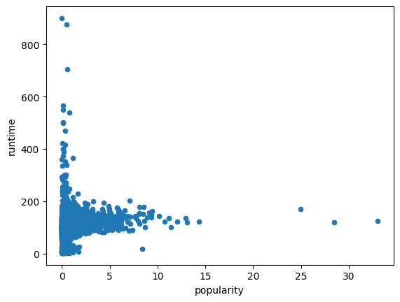

```python
df.plot(y='runtime' , x='popularity' , kind="scatter");
```

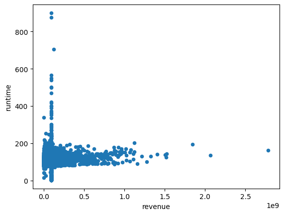

```python
df.plot(y='runtime' , x='revenue', kind="scatter" );
```

## Answer:

### In Summary:

runtime does not appear to correlate strongly with either popularity or revenue.

### Runtime Vs. Popularity:

The points are concentrated in a dense cluster where movies with shorter runtimes (under 200 minutes) appear across the entire range of popularity scores.

There doesn’t seem to be a strong positive or negative correlation between runtime and popularity. Some movies with shorter runtimes are highly popular, while others are not, and the popularity score doesn’t consistently increase with runtime.

The data suggests that runtime does not have a significant correlation with popularity; popular movies can be either long or short.

### Runtime vs. Revenue:

Similar to the popularity plot, there is a dense cluster of movies with runtimes under 200 minutes, which span a wide range of revenue values.

There is no clear upward or downward trend, indicating that longer movies do not necessarily earn more revenue, and shorter movies do not necessarily earn less.

Therefore, runtime does not show a strong correlation with revenue either; high-revenue movies can have various runtimes.

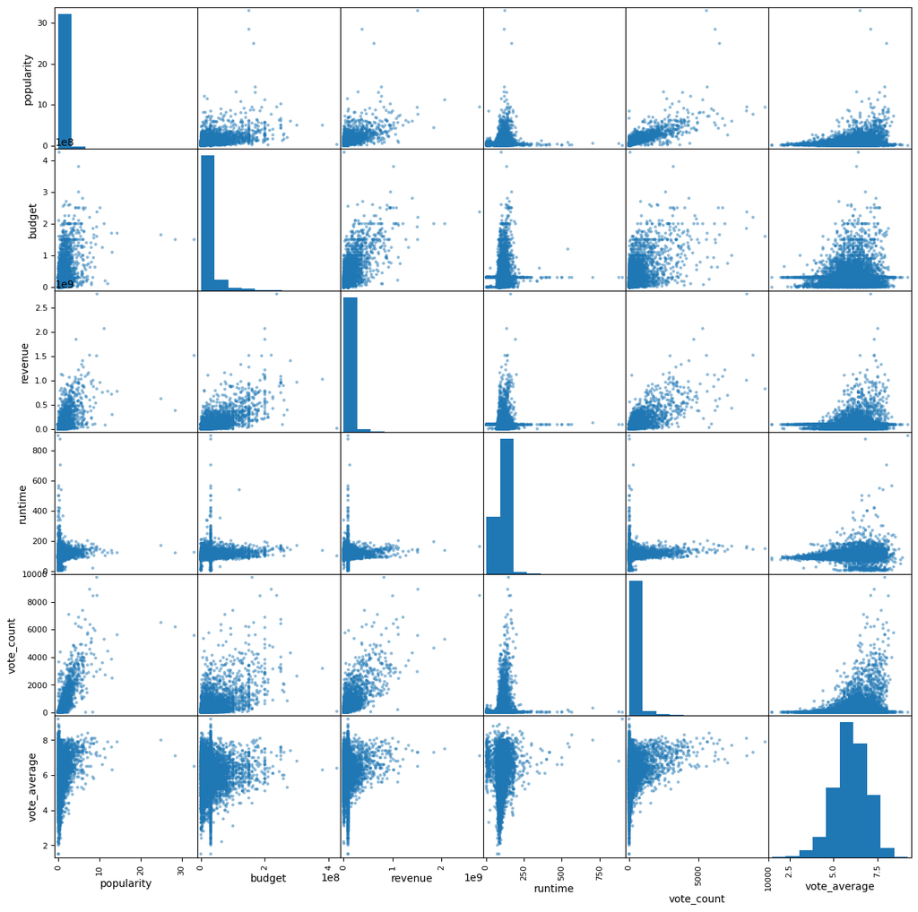

```python
#if we further look at runtime column corrolations with other columns
pd.plotting.scatter_matrix(df.iloc[:, 1:] , figsize=(15,15));
# i used df.iloc[:, 1:] to draw the matrix without the id col
```

### Further Investigation

if we look here at the relationship between the runtime and all other columns it also doesnt have a negative or positive corrolation meaning it doesn't affect a movies revenue nor popularity.

### Question 2: Which directors have the most high-revenue movies?

```python
# assuming the high revenue movies are the ones higher than 50% of the movies
high_revenue = df['revenue'].quantile(0.5)

# getting the hight 50% rvenue movies
high_revenue_df = df[df['revenue'] >= high_revenue]

# counting directors with high revenue movies
director_counts = high_revenue_df['director'].value_counts()

director_counts.head()
```

```
Woody Allen         26
Steven Spielberg    25
Clint Eastwood      19
Martin Scorsese     19
Ron Howard          16
Name: director, dtype: int64
```

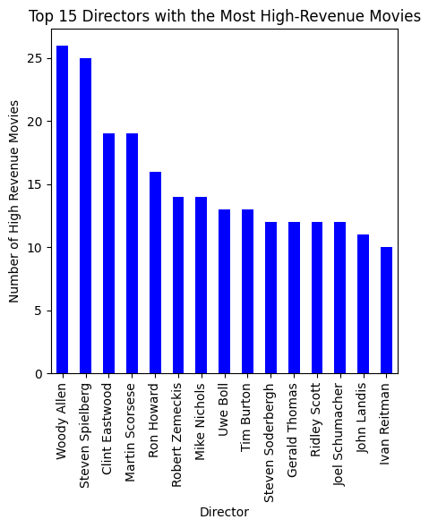

```python
#getting top 15 direcots
top_directors = director_counts.head(15)

# plotting high revenue movies Vs their directors
top_directors.plot(figsize=(5,5), title="Top 15 Directors with the Most High-Revenue Movies" , xlabel="Director", ylabel="Number of High Revenue Movies" , kind='bar', color='blue');
```

### Answer:

I defined high-revenue movies as those with revenue above the median (50th percentile) revenue of all movies.

According to the plot:

It appears that Woody Allen, Steven Spielberg, Clint Eastwood, Martin Scorsese, and Ron Howard are among the directors with the highest number of high-revenue movies. This suggests that these directors frequently produce movies that perform well financially, indicating both their popularity and potential ability to consistently attract large audiences.

This plot provides a clear, ranked view of which directors have directed the most high-revenue movies.

### Question 3: Which movies are most popular from year to year?

```python
#lets get most popular movies
most_pop = df['popularity'].quantile(0.5)

# getting the hight 50% rvenue movies
most_pop_df = df[df['popularity'] >= most_pop]

# counting most popular movies according to their release year
years_count = most_pop_df['release_year'].value_counts()

years_count
```

```
2014    339
2015    320
2013    298
2011    292
2009    264
2012    261
2010    253
2008    245
2007    233
2006    210
2005    194
2004    174
2003    150
2002    149
2001    133
```

[output cut: 42 more lines]

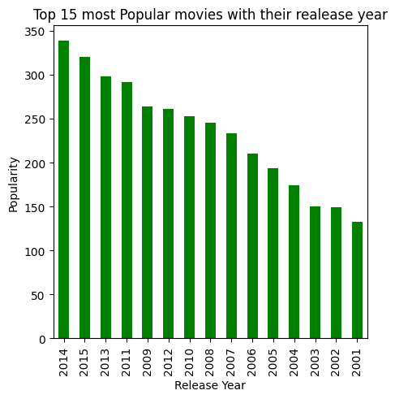

```python
#plotting a graph for most 15 popular movies according to their release year
years_count.head(15).plot(figsize=(5,5), title="Top 15 most Popular movies with their realease year" , xlabel="Release Year", ylabel="Popularity" , kind='bar', color='green');
```

### Question 4: What kinds of properties are associated with movies that have high revenues?

```python
#we already got the high revenue movies in the variable high_revenue_df
#now i wanna get their categories at first

#genres are saved in series. i want to explode better for investigation
high_revenue_df = high_revenue_df.assign(genres=high_revenue_df['genres']).explode('genres') #chatgpt

#getting genres with high revenue movies
top_genres = high_revenue_df['genres'].value_counts()

top_genres
```

```
Drama              2941
Comedy             2500
Thriller           1873
Action             1606
Horror             1176
Romance            1041
Adventure          1031
Family              955
Science Fiction     865
Crime               769
Fantasy             672
Animation           587
Mystery             516
Documentary         410
Music               262
History             216
War                 181
TV Movie            161
Foreign             155
Western             118
Name: genres, dtype: int64
```

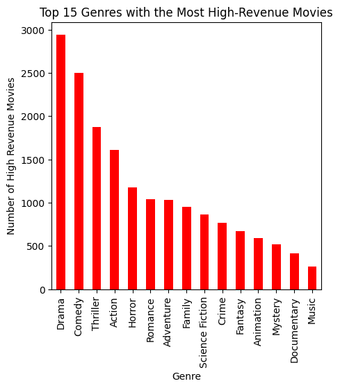

```python
#plotting graph
top_genres.head(15).plot(figsize=(5,5), title="Top 15 Genres with the Most High-Revenue Movies" , xlabel="Genre", ylabel="Number of High Revenue Movies" , kind='bar', color='red');
```

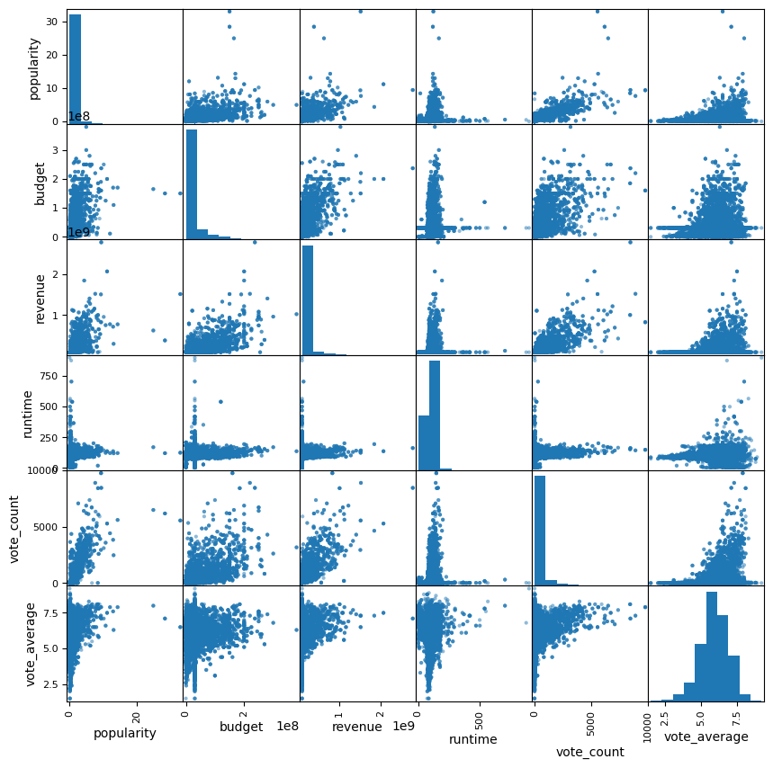

```python
#since we have a high revenue df
#let me draw a matrix to view its corrolations better

pd.plotting.scatter_matrix(high_revenue_df.iloc[: , 1:] , figsize=(10,10));
```

### Answer:

From the scatter plot matrix, we can observe the following trends:

##### Popularity and Revenue:

There seems to be a positive correlation between popularity and revenue, suggesting that more popular movies tend to generate higher revenue.

##### Budget and Revenue:

There's also a noticeable positive correlation between budget and revenue. Higher budgets may contribute to higher production quality, marketing reach, and distribution, all of which could drive up revenue.

##### Runtime and Revenue:

There’s no strong correlation between runtime and revenue, suggesting that longer or shorter films are not necessarily associated with higher revenue.

##### Vote Average and Revenue:

There is a moderate positive trend, showing that higher-rated movies tend to have higher revenue, although this relationship is not as strong as with popularity and vote count.

## Conclusions

I started at first by cleaning and organizing my data set of movies. (I removedd unnecessary columns, removed duplicates, converted data types to optimize memory usage)

I asked some questions about the data andd here is what i found:

### 1- Does the runtime of a movie correlate with its popularity or revenue?

The runtime of a movie does not significantly influence either its popularity or revenue. Scatter plot analysis shows no strong correlation between runtime and popularity or revenue, as movies with various runtimes are distributed across all popularity and revenue levels. High-popularity or high-revenue movies can have short or long runtimes, indicating that runtime is not a determining factor in a movie's success in terms of popularity or financial performance.

### 2- Which directors have the most high-revenue movies?

Directors like Woody Allen and Steven Spielberg have repeatedly directed high-revenue movies, highlighting their impact and popularity in the film industry. This analysis reflects that certain directors are strongly associated with financially successful films, possibly due to factors like established fan bases, genre specialization, or storytelling style.

### Faced limitations:

##### Bias Toward More Recent Movies:

As seen in the popularity chart, recent movies are more represented among popular titles. This could be due to factors like improved global distribution or online marketing rather than intrinsic quality or appeal, leading to potential bias. Older movies might not have the same level of recorded popularity or revenue data, skewing analysis.

##### Limited Genre Information:

The genres column contains multiple genres per movie, which can make it difficult to isolate the impact of individual genres on revenue or popularity. The analysis assumes that all genres listed for a movie contribute equally to its popularity or revenue, which may not be accurate.

### Further Investigation

Analyze Genre Combinations: Since movies often belong to multiple genres, you could explore which genre combinations are associated with higher revenue or popularity. For instance, comparing "Action | Adventure" movies against "Comedy | Romance" might yield insights into the profitability of genre blends.

Investigate Trends Over Time: Explore how certain attributes (like budget, runtime, and genre popularity) have evolved over different periods. Are there shifts in preferred movie lengths, budgets, or genre popularity over the years?

Study Director and Actor Influence: Examine the impact of certain directors or popular actors on a movie's success. Do movies directed by well-known directors or starring specific actors tend to have higher revenue or popularity?

Audience Reviews and Ratings Analysis: Look into the relationship between vote average, vote count, and popularity. Do highly rated movies also tend to be the most popular or profitable, or is there a discrepancy between audience ratings and revenue?

Analyze Changes in Movie-Making Trends: Investigate changes in film-making attributes (e.g., genre focus, runtime, budgets) over time to see how the industry adapts to audience preferences or technological advancements.

```python
# Running this cell will execute a bash command to convert this notebook to an .html file
!python -m nbconvert --to html Investigate_a_Dataset.ipynb
```

```
[NbConvertApp] Converting notebook Investigate_a_Dataset.ipynb to html
[NbConvertApp] WARNING | Alternative text is missing on 7 image(s).
[NbConvertApp] Writing 1347661 bytes to Investigate_a_Dataset.html
```